# Link redness indices with HPLC astaxanthin content

Laure Vilgrain

January 2023

```r
library("tidyverse")
library("patchwork")
library("viridis")
library("ggrepel")
```

# 0. Read datasets

```r
img_details <- read_csv("data_emilia/img_details.csv")
asta_samples <- read_csv("data_emilia/asta_samples.csv")
red_ind_final <- read_csv("data_emilia/red_ind_final.csv") %>% rename(image_name = img_name)
```

# 1. Merge with redness indices dataset (from python)

```r
img_details <- img_details %>% left_join(red_ind_final)
red_index_by_sample <- img_details %>%
  group_by(sample_name) %>%
  summarise(sample_redness = mean(redness_index), sample_red_pixels = mean (red_pixels_nb)) %>%
  left_join(asta_samples, by = "sample_name") %>%
  mutate(asta_ng = asta_ng_mg*mass_mg)
```

# 2. Regressions

## 2.1. Average redness index vs total astaxanthin content per tube (ng)

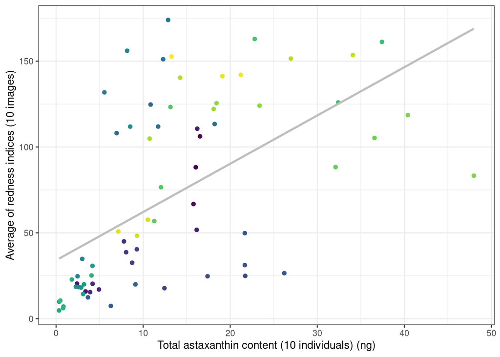

```r
ggplot(red_index_by_sample)+
  geom_point(aes(x = asta_ng, y = sample_redness, color = sample_name))+
  geom_smooth(aes(x = asta_ng, y = sample_redness), method = "lm", color = "grey", se= F)+
  labs(x= "Total astaxanthin content (10 individuals) (ng)", y ="Average of redness indices (10 images)")+
  theme_bw()+ theme(legend.position = "none") +
  scale_color_viridis_d()
```

```r
test <- lm(asta_ng ~ sample_redness, data = red_index_by_sample)
summary(test)
```

```
##
## Call:
## lm(formula = asta_ng ~ sample_redness, data = red_index_by_sample)
##
## Residuals:
##     Min      1Q  Median      3Q     Max
## -14.723  -5.056  -2.010   1.673  33.478
##
## Coefficients:
##                Estimate Std. Error t value Pr(>|t|)
## (Intercept)     4.90733    1.78255   2.753  0.00757 **
## sample_redness  0.11518    0.02018   5.706 2.75e-07 ***
## ---
## Signif. codes:  0 '***' 0.001 '**' 0.01 '*' 0.05 '.' 0.1 ' ' 1
##
## Residual standard error: 8.932 on 68 degrees of freedom
## Multiple R-squared:  0.3238, Adjusted R-squared:  0.3139
## F-statistic: 32.56 on 1 and 68 DF,  p-value: 2.749e-07
```

*Significant <0.001, adjusted R-squared = 31%*

## 2.2. Average redness index vs astaxanthin content per copepod (ng/mgDW)

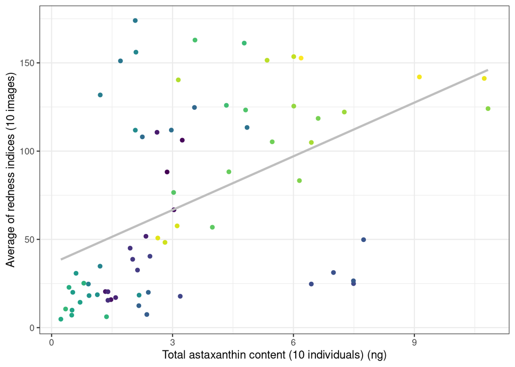

```r
ggplot(red_index_by_sample)+
  geom_point(aes(x = asta_ng_mg, y = sample_redness, color = sample_name))+
  geom_smooth(aes(x = asta_ng_mg, y = sample_redness), method = "lm", color = "grey", se= F)+
  labs(x= "Total astaxanthin content (10 individuals) (ng)", y ="Average of redness indices (10 images)")+
  theme_bw()+ theme(legend.position = "none")  +
  scale_color_viridis_d()
```

```r
test <- lm(asta_ng_mg ~ sample_redness, data = red_index_by_sample)
summary(test)
```

```
##
## Call:
## lm(formula = asta_ng_mg ~ sample_redness, data = red_index_by_sample)
##
## Residuals:
##     Min      1Q  Median      3Q     Max
## -3.7103 -1.4166 -0.5592  0.6685  6.1954
##
## Coefficients:
##                Estimate Std. Error t value Pr(>|t|)
## (Intercept)    1.766205   0.447434   3.947  0.00019 ***
## sample_redness 0.023100   0.005067   4.559  2.2e-05 ***
## ---
## Signif. codes:  0 '***' 0.001 '**' 0.01 '*' 0.05 '.' 0.1 ' ' 1
##
## Residual standard error: 2.242 on 68 degrees of freedom
## Multiple R-squared:  0.2341, Adjusted R-squared:  0.2229
## F-statistic: 20.79 on 1 and 68 DF,  p-value: 2.199e-05
```

*Significant <0.001, adjusted R-squared = 22%* > expected because here astaxanthin content is normalized by copepod weight, but as we took a sum of total astaxanthin content for 10 images, it has to be compared to the total per sample. We see group by samples, because copepods were typically assembled by size and astaxanthin content.

## 2.3. Total number of red pixels vs total astaxanthin content (ng)

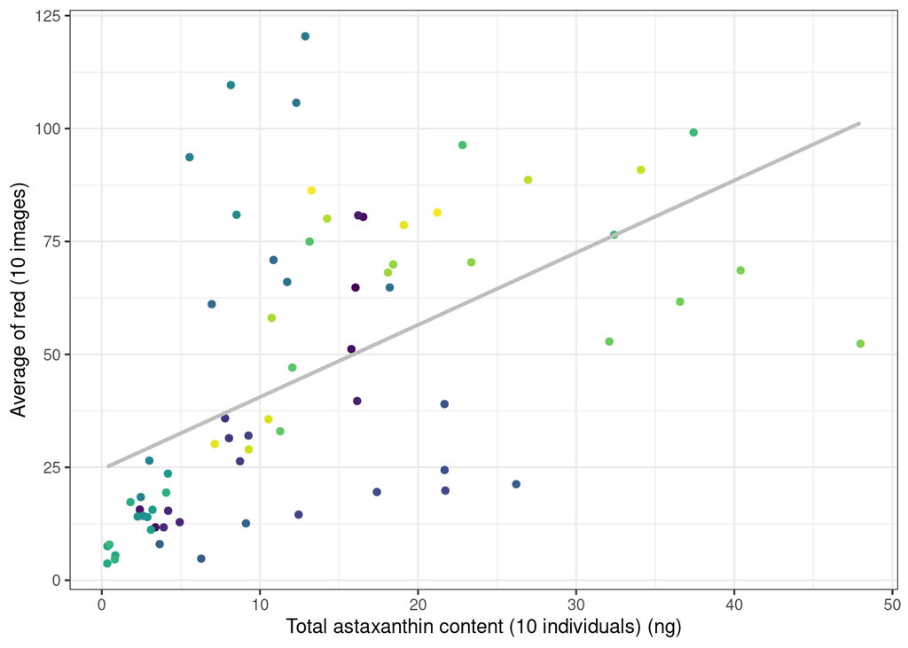

```r
ggplot(red_index_by_sample)+
  geom_point(aes(x = asta_ng, y = sample_red_pixels, color = sample_name))+
  geom_smooth(aes(x = asta_ng, y = sample_red_pixels), method = "lm", color = "grey", se= F)+
  labs(x= "Total astaxanthin content (10 individuals) (ng)", y ="Average of red (10 images)")+
  theme_bw()+ theme(legend.position = "none")  +
  scale_color_viridis_d()
```

```r
test <- lm(asta_ng ~ sample_red_pixels, data = red_index_by_sample)
summary(test)
```

```
##
## Call:
## lm(formula = asta_ng ~ sample_red_pixels, data = red_index_by_sample)
##
## Residuals:
##     Min      1Q  Median      3Q     Max
## -16.496  -5.063  -2.741   1.686  33.672
##
## Coefficients:
##                   Estimate Std. Error t value Pr(>|t|)
## (Intercept)        4.84436    1.90743   2.540   0.0134 *
## sample_red_pixels  0.18069    0.03438   5.256 1.61e-06 ***
## ---
## Signif. codes:  0 '***' 0.001 '**' 0.01 '*' 0.05 '.' 0.1 ' ' 1
##
## Residual standard error: 9.16 on 68 degrees of freedom
## Multiple R-squared:  0.2889, Adjusted R-squared:  0.2784
## F-statistic: 27.62 on 1 and 68 DF,  p-value: 1.608e-06
```

*Significant <0.001, adjusted R-squared = 28%* > not a big difference with quantitative index

# 3. Check variability among images

So we will keep the first regression, and see variability among images.

```r
# Dataset with HPLC quantification associated to each image (not summarise to sample level)
red_index_by_image <- img_details %>%
  group_by(sample_name) %>%
  mutate(sample_redness = mean(redness_index), sample_red_pixels = mean(red_pixels_nb)) %>%
  left_join(select(asta_samples, sample_name,asta_ng_mg,mass_mg), by = "sample_name") %>%
  mutate(asta_ng = asta_ng_mg*mass_mg)
```

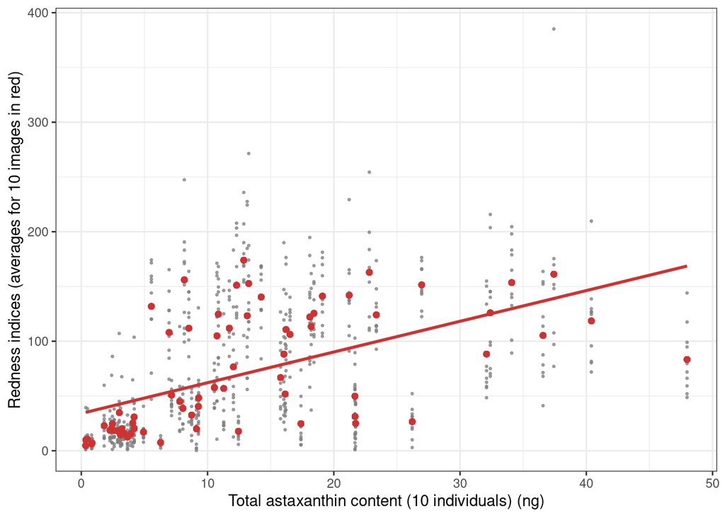

```r
ggplot(red_index_by_image)+
  geom_point(aes(x = asta_ng, y = redness_index), color = "grey50", alpha = 0.7, size = 0.5)+
    geom_point(aes(x = asta_ng, y = sample_redness), color = "brown3", size = 1.5)+
  geom_smooth(aes(x = asta_ng, y = sample_redness), method = "lm", color = "brown3", aplha = 0.7, se= F)+
  labs(x= "Total astaxanthin content (10 individuals) (ng)", y ="Redness indices (averages for 10 images in red)")+
  theme_bw()
```

We can see something like a saturation (which was proven for salmon redness, Ronsholdt & McLean 2001) :

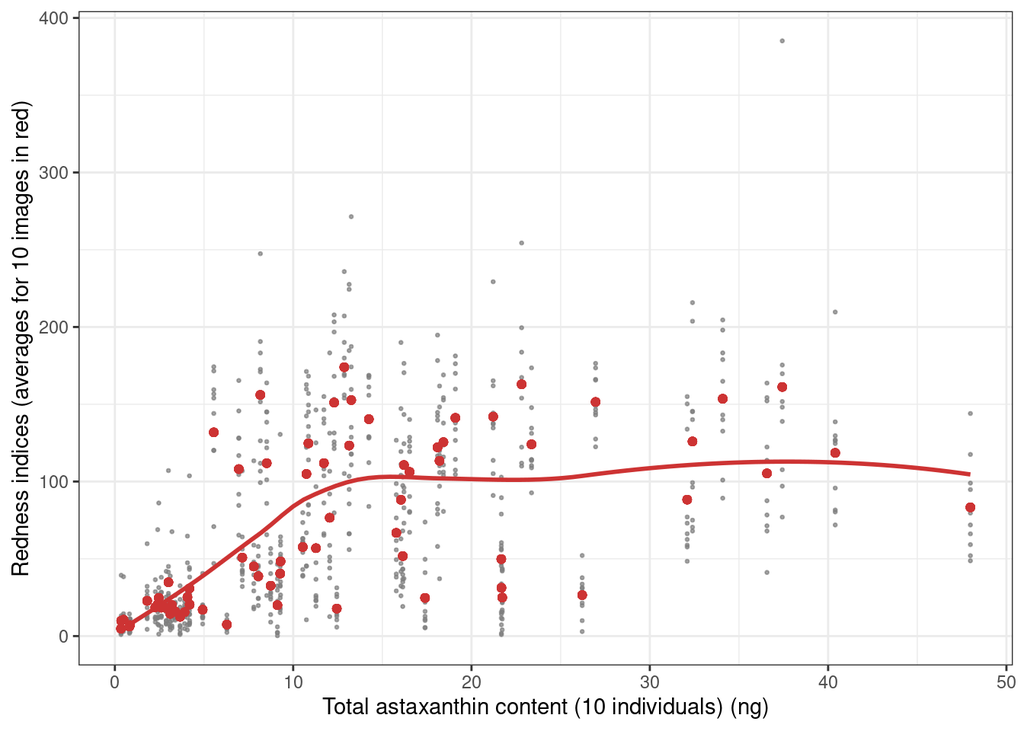

```r
ggplot(red_index_by_image)+
  geom_point(aes(x = asta_ng, y = redness_index), color = "grey50", alpha = 0.7, size = 0.5)+
  geom_point(aes(x = asta_ng, y = sample_redness), color = "brown3", size = 1.5)+
  geom_smooth(aes(x = asta_ng, y = sample_redness), color = "brown3", aplha = 0.7, se= F)+
  labs(x= "Total astaxanthin content (10 individuals) (ng)", y ="Redness indices (averages for 10 images in red)")+
  theme_bw()
```

Is this saturation because of - a “real” trend ? - HPLC methods variability at medium concentrations ? - uncertainties in the redness index method (threshold not optimal) ? - because of outliers ?

# 4. Look deeper

## 4.1 Check outliers

```r
# Define outliers
expected_outliers_high <- red_index_by_image %>% filter(redness_index > 200)
expected_outliers_low <- red_index_by_image %>% filter(redness_index < 50 & asta_ng >15)
```

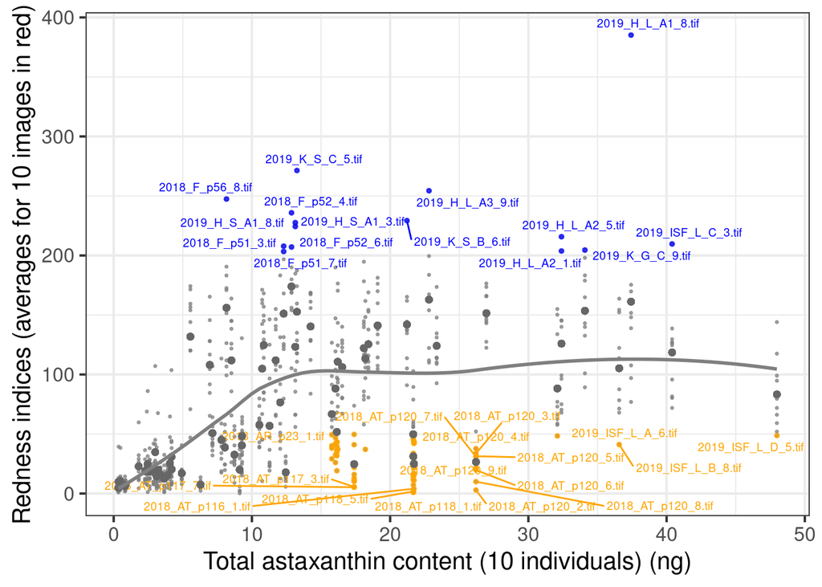

```r
ggplot(red_index_by_image)+
  geom_point(aes(x = asta_ng, y = redness_index), color = "grey50", alpha = 0.7, size = 0.5)+
  geom_point(aes(x = asta_ng, y = redness_index), color = "blue", alpha = 0.7, size = 1, data = expected_outliers_high)+
  geom_text_repel(aes(x = asta_ng, y = redness_index, label = image_name), color = "blue", data = expected_outliers_high, size =2.5, max.overlaps = 15)+
  geom_point(aes(x = asta_ng, y = redness_index), color = "orange", alpha = 0.7, size = 1, data = expected_outliers_low)+
  geom_text_repel(aes(x = asta_ng, y = redness_index, label = image_name), color = "orange", data = expected_outliers_low, size =2.5, max.overlaps =30 )+
  geom_point(aes(x = asta_ng, y = sample_redness), color = "grey40", size = 1.5)+
  geom_smooth(aes(x = asta_ng, y = sample_redness), color = "grey50", aplha = 0.7, se= F)+
  labs(x= "Total astaxanthin content (10 individuals) (ng)", y ="Redness indices (averages for 10 images in red)")+
  theme_bw(base_size=15)
```

```r
ggsave("results/index_outliers.png", width=12, height =10)
```

## 4.2 Look at the effect of the year

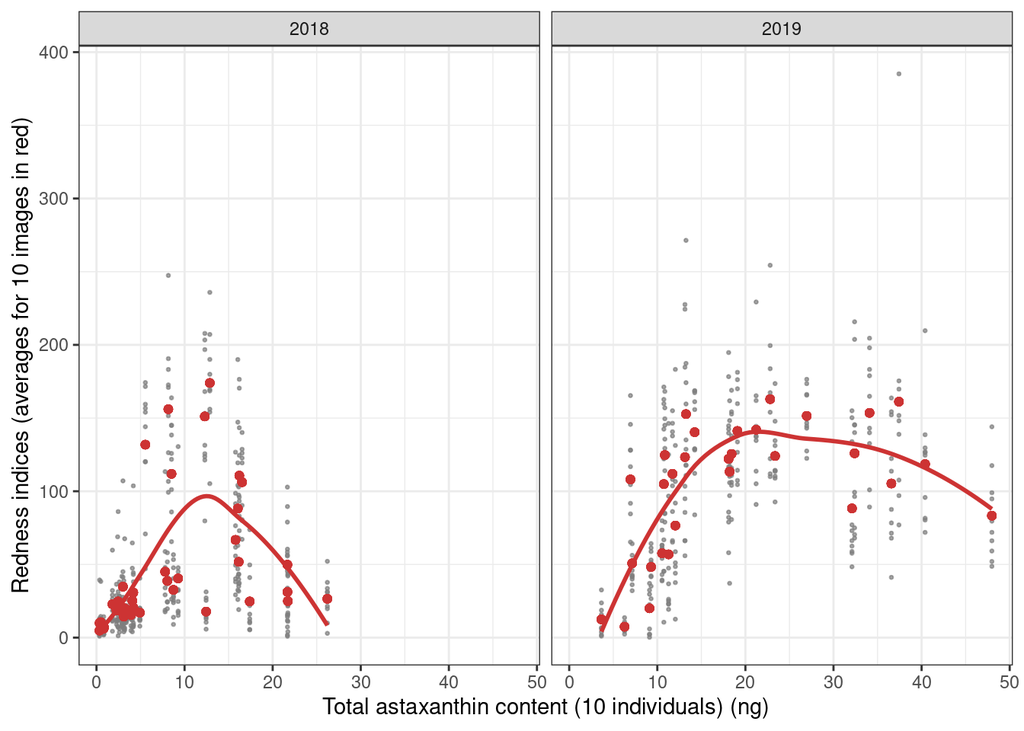

```r
red_index_by_image %>%
  ggplot()+
  facet_wrap(~ year)+
  geom_point(aes(x = asta_ng, y = redness_index), color = "grey50", alpha = 0.7, size = 0.5)+
  geom_point(aes(x = asta_ng, y = sample_redness), color = "brown3", size = 1.5)+
  geom_smooth(aes(x = asta_ng, y = sample_redness), color = "brown3", aplha = 0.7, se= F)+
  labs(x= "Total astaxanthin content (10 individuals) (ng)", y ="Redness indices (averages for 10 images in red)")+
  theme_bw()
```

Focus on 2018 :

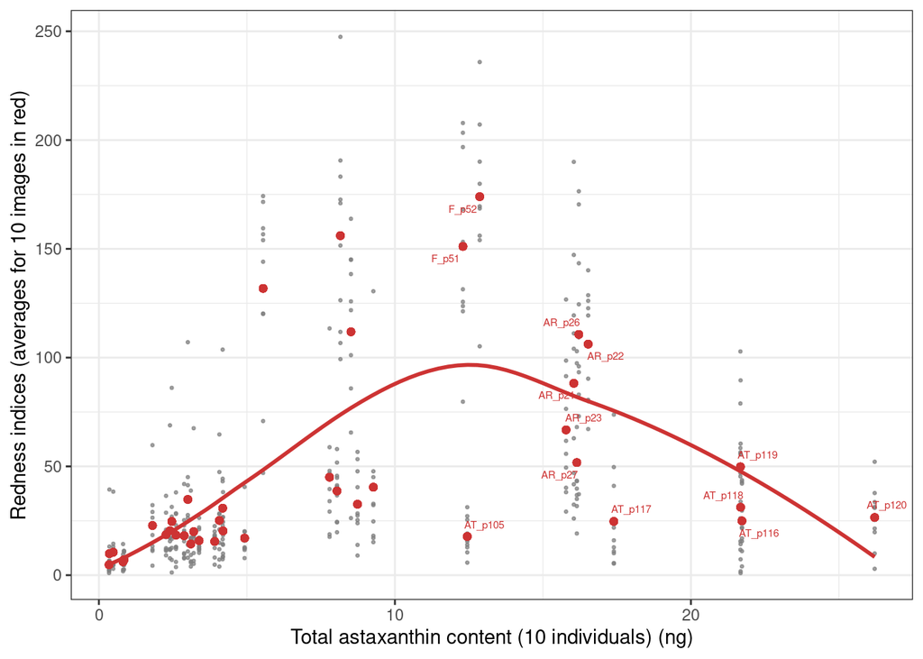

```r
extreme_2018 <- red_index_by_image %>%
  filter(year == 2018 & asta_ng > 10) %>%
  group_by(sample_name) %>%
  summarise(sample_redness = mean(sample_redness), asta_ng = mean(asta_ng))

red_index_by_image %>%
  filter(year == 2018) %>%
  ggplot()+
  geom_point(aes(x = asta_ng, y = redness_index), color = "grey50", alpha = 0.7, size = 0.5)+
  geom_point(aes(x = asta_ng, y = sample_redness), color = "brown3", size = 1.5)+
  geom_text_repel(aes(x = asta_ng, y = sample_redness, label = sample_name), color = "brown3", size = 2, max.overlaps =30, data = extreme_2018)+
  geom_smooth(aes(x = asta_ng, y = sample_redness), color = "brown3", aplha = 0.7, se= F)+
  labs(x= "Total astaxanthin content (10 individuals) (ng)", y ="Redness indices (averages for 10 images in red)")+
  theme_bw()
```

```r
ggsave("results/index_outliers_2018.png", width=8, height =8)
```